# Lab 12: Beyond the General Linear Model

Ednita Tavarez-Jimenez

#Lowess

**Q1: Include your plot in your lab report.**

```r
require(here)
dat_bird <- read.csv(here("data", "bird.sub.csv"))
dat_hab <- read.csv(here("data", "hab.sub.csv"))
birdhab <- merge(dat_bird, dat_hab)
dim(birdhab)
```

```
## [1]  30 159
```

```r
fit_1 <- lm(birdhab$BRCR ~ birdhab$ls, data = birdhab)
```

```r
#Build Simulation

fit_1_coefs = coefficients(fit_1)
str(fit_1_coefs)
```

```
##  Named num [1:2] 0.0991 0.00584
##  - attr(*, "names")= chr [1:2] "(Intercept)" "birdhab$ls"
```

```r
fit_1_summary = summary(fit_1)
str(fit_1_summary)
```

[output not shown]

```r
fit_1_summary$sigma
```

```
## [1] 0.1412668
```

```r
int_obs <- fit_1_coefs[1]
slope_obs <- fit_1_coefs [2]
sd_obs <- fit_1_summary$sigma
```

```r
alpha = 0.05
n_sims = 30
p_vals = numeric(n_sims)

sample_sizes = seq(5, 20)
sample_size_powers = numeric(length(sample_sizes))

# The maximum x value in the simulation.
# Use the maximum observed x-value in the data
max_x = max(birdhab$ls)

linear = function(x, y_int, slope)
{
  return(x*slope + y_int)

}

linear(x = 1, y_int = 1, slope = 1)
```

```
## [1] 2
```

```r
linear(x = 3:5, y_int = 1, slope = 1)
```

```
## [1] 4 5 6
```

```r
linear(x = 3:5, y_int = -1, slope = 1)
```

```
## [1] 2 3 4
```

```r
linear(x = 3:5, y_int = -1, slope = 0.01)
```

```
## [1] -0.97 -0.96 -0.95
```

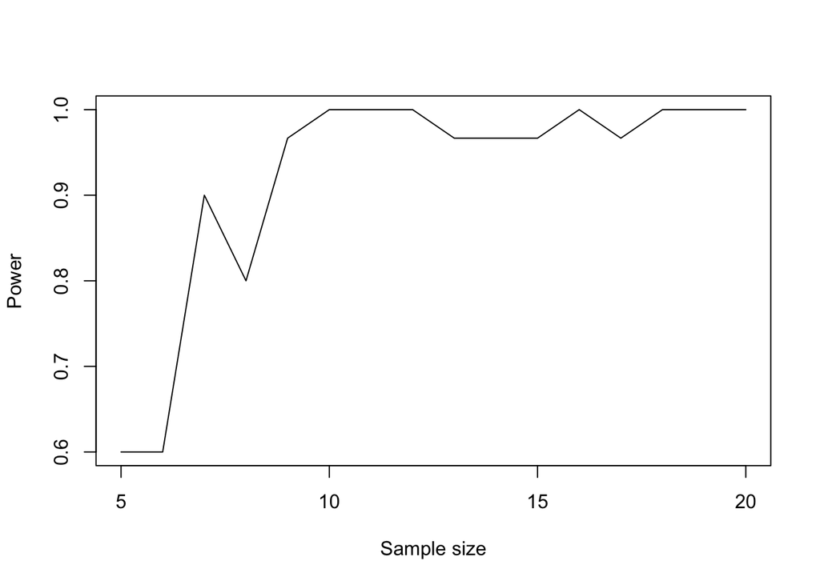

```r
linear_simulator = function (x, y_int, slope, st_dev)
{

  int_1 <- linear(x, y_int, slope)
  noise <- rnorm(n = length(x), mean = 0, sd = st_dev)
  noisy_line <- int_1 + noise

  return(noisy_line)

}

linear_sim_fit = function(x, slope, y_int, st_dev)
{
  y_sim = linear_simulator(
    x = x,
    y_int = y_int,
    slope = slope,
    st_dev = st_dev
  )
  fit_sim = lm(y_sim ~ x)
  return(fit_sim)
}


for(j in 1:length(sample_sizes))
{
  # A sequence of equally-spaced x-values:
  x_vals = seq(0, max_x, length.out = sample_sizes[j])

  for(i in 1:n_sims)
  {
    fit_sim = linear_sim_fit(
      x = x_vals,
      y_int = int_obs,
      slope = slope_obs,
      st_dev = sd_obs
    )
    p_vals[i] = summary(fit_sim)$coefficients[2, 'Pr(>|t|)']
  }
  sample_size_powers[j] = sum(p_vals < alpha) / n_sims
}


sim_sample_size =
  data.frame(
    sample_size = sample_sizes,
    power       = sample_size_powers)

plot(
  power ~ sample_size, data = sim_sample_size,
  type = 'l', xlab = 'Sample size', ylab = 'Power')
```

```r
fit_lowess_50 = loess(power ~ sample_size, data = sim_sample_size, span = 0.5)
```

```r
newdata_sample_size = data.frame(sample_size = seq(2, 20, length.out = 100))
```

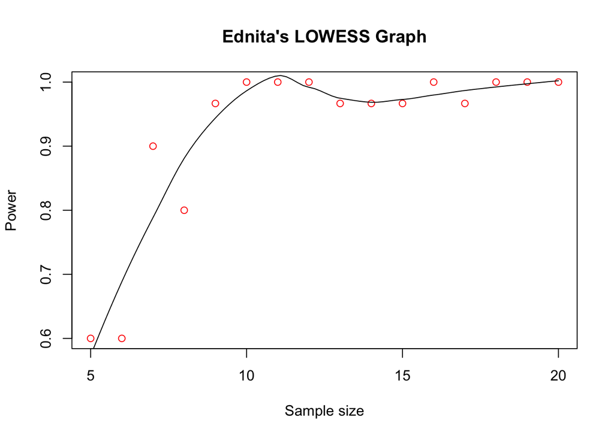

```r
plot(
  power ~ sample_size, data = sim_sample_size,
  type = 'p', xlab = 'Sample size', ylab = 'Power', col = "red", main = "Ednita's LOWESS Graph")

points(
  x = newdata_sample_size$sample_size,
  y = predict(fit_lowess_50, newdata = newdata_sample_size),
  type = "l", add = TRUE,
  ylab = "Statistical Power", xlab = "Sample Size", lty = "solid")
```

# NLS

**Q2: Include your plot in your lab report.**

Instructions

Follow the lab walkthrough and make sure you can recreate the plots. Review the exponential model you fit in lab 5. Fit an NLS exponential model to the marbled salamander data. Create a plot of your NLS and visually-fitted exponential models. Your plot must include: A line for your visually-estimated model. A line for your model fit via NLS. Appropriate legend, title, and axis labels.

```r
require(here)
here()
```

```
## [1] "/Users/ednitatavarez/Environmental Data/Environmental_Data"
```

```r
dat_dispersal = read.csv(
  here("data", "dispersal.csv"))

line_point_slope = function(x, x1, y1, slope)
  {
    get_y_intercept =
      function(x1, y1, slope)
        return(-(x1 * slope) + y1)

    linear =
      function(x, yint, slope)
        return(yint + x * slope)

    return(linear(x, get_y_intercept(x1, y1, slope), slope))
}

plot(
    dat_dispersal$dist.class,
    dat_dispersal$disp.rate.ftb,
    xlim = c(0, 1500),
    xlab = "distance class",
    ylab = "standardized dispersal rate",
    main = "Ednita's Marbled Salamander Plot - first time breeders")

ricker_fun = function(x, a, b)
{
  return(a * x * exp(-b * x))
}

exp_fun = function(x, a, b)

{
  return(a * exp(-b * x))
}


fit_ricker_nls = nls(
  disp.rate.ftb ~ ricker_fun(dist.class, a, b),
  data = dat_dispersal,
  start = list(b = 0, a = 1))
summary(fit_ricker_nls)
```

```
##
## Formula: disp.rate.ftb ~ ricker_fun(dist.class, a, b)
##
## Parameters:
##   Estimate Std. Error t value Pr(>|t|)
## b 0.003586   0.000913   3.928  0.00201 **
## a 0.004471   0.001889   2.367  0.03558 *
## ---
## Signif. codes:  0 '***' 0.001 '**' 0.01 '*' 0.05 '.' 0.1 ' ' 1
##
## Residual standard error: 0.2149 on 12 degrees of freedom
##
## Number of iterations to convergence: 17
## Achieved convergence tolerance: 9.065e-06
##   (1 observation deleted due to missingness)
```

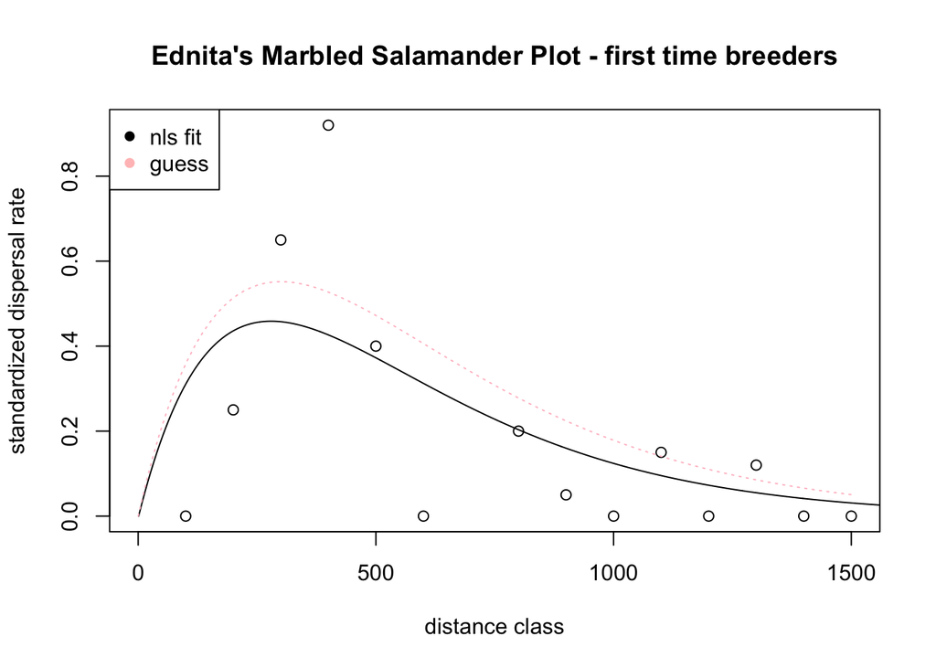

```r
#first step is to make a data frame

dist_newdata = data.frame(dist.class = seq(0, 1600, length.out = 1600))


#plot the results of our model

lines(predict(fit_ricker_nls, newdata = dist_newdata))
legend(
  "topleft",
  legend = c("nls fit", "guess"),
  pch = 16,
  col = c(1, adjustcolor("red", alpha = 0.3)))


curve(ricker_fun(x, .005, 1/300),
  from = 0, to = 1500, add = TRUE, ylim = c(0,1500),
  ylab = "f(x)", xlab = "x",col = "pink", lty = "dotted")
```

# Logistic Models 1: Model Fits

**Q3: What are the AIC values for each of the 4 models?**

```r
dat_bird = read.csv(here("data", "bird.sta.csv"))
dat_habitat = read.csv(here("data", "hab.sta.csv"))
dat_all = merge(dat_bird, dat_habitat)

dat_all$GCKI_pres = dat_all$GCKI > 0

# Hermit warbler presence/absence
dat_all$GCKI_pres = dat_all$GCKI > 0

# Create model fits
fit_gcki_slope = glm(GCKI_pres ~ slope, data = dat_all, family = binomial)
fit_gcki_ba_tot = glm(GCKI_pres ~ ba.tot, data = dat_all, family = binomial)
fit_gcki_both_additive = glm(GCKI_pres ~ slope + ba.tot, data = dat_all, family = binomial)
fit_gcki_both_interactive = glm(GCKI_pres ~ slope * ba.tot, data = dat_all, family = binomial)

summary(fit_gcki_both_additive)
```

```
##
## Call:
## glm(formula = GCKI_pres ~ slope + ba.tot, family = binomial,
##     data = dat_all)
##
## Deviance Residuals:
##    Min      1Q  Median      3Q     Max
## -3.485  -1.101   0.681   1.076   1.664
##
## Coefficients:
##              Estimate Std. Error z value Pr(>|z|)
## (Intercept)  0.129095   0.175345   0.736 0.461589
## slope       -0.011698   0.003008  -3.889 0.000101 ***
## ba.tot       0.031067   0.003840   8.091 5.89e-16 ***
## ---
## Signif. codes:  0 '***' 0.001 '**' 0.01 '*' 0.05 '.' 0.1 ' ' 1
##
## (Dispersion parameter for binomial family taken to be 1)
##
##     Null deviance: 1439.7  on 1045  degrees of freedom
## Residual deviance: 1350.0  on 1043  degrees of freedom
## AIC: 1356
##
## Number of Fisher Scoring iterations: 3
```

```r
n = 500

slope_newdata = data.frame(
  slope = seq(
    from = min(dat_all$slope, na.rm = T),
    to = max(dat_all$slope, na.rm = T),
    length.out = n
  )
)

#new data.frame of total basal area values for prediction. Call it ba_newdata.

ba_newdata = data.frame(
  ba.tot = seq(
    from = min(dat_all$ba.tot, na.rm = T),
    to = max(dat_all$ba.tot, na.rm = T),
    length.out = n))


slope_newdata$gcki_predicted =
  predict(
    fit_gcki_slope,
    newdata = slope_newdata,
    type = "response"
  )

ba_newdata$gcki_predicted =
  predict(
    fit_gcki_ba_tot,
    newdata = ba_newdata,
    type = "response"
  )

#Compare models using AIC

AIC(
  fit_gcki_ba_tot,
  fit_gcki_slope,
  fit_gcki_both_additive,
  fit_gcki_both_interactive)
```

```
##                           df      AIC
## fit_gcki_ba_tot            2 1369.379
## fit_gcki_slope             2 1432.615
## fit_gcki_both_additive     3 1355.951
## fit_gcki_both_interactive  4 1353.007
```

**Q4: Which model would you choose, and why?**

I would choose the AIC model because it’ll show me the best model to use, in this case it would be fit_gcki_both_interactive.

```r
n = 50

ba.tot = seq(
  from = min(dat_all$ba.tot, na.rm = T),
  to = max(dat_all$ba.tot, na.rm = T),
  length.out = n)
slope = seq(
  from = min(dat_all$slope, na.rm = T),
  to = max(dat_all$slope, na.rm = T),
  length.out = n)

new_dat_all = expand.grid(
  ba.tot = ba.tot,
  slope = slope)
head(new_dat_all)
```

```
##     ba.tot slope
## 1  0.00000     0
## 2  4.22449     0
## 3  8.44898     0
## 4 12.67347     0
## 5 16.89796     0
## 6 21.12245     0
```

```r
tail(new_dat_all)
```

```
##        ba.tot slope
## 2495 185.8776   110
## 2496 190.1020   110
## 2497 194.3265   110
## 2498 198.5510   110
## 2499 202.7755   110
## 2500 207.0000   110
```

```r
new_dat_all$pred_add = predict(
  fit_gcki_both_additive,
  newdata = new_dat_all,
  type = "response")

new_dat_all$pred_int = predict(
  fit_gcki_both_interactive,
  newdata = new_dat_all,
  type = "response")

z_gcki_add = matrix(
  new_dat_all$pred_add,
  nrow = length(ba.tot),
  byrow = FALSE)

z_gcki_int = matrix(
  new_dat_all$pred_int,
  nrow = length(ba.tot),
  byrow = FALSE)

#3D plot

require(rgl)
rgl::persp3d(
  x = ba.tot,
  y = slope,
  z = z_gcki_add,
  col = "pink",
  xlab = "Basal Area",
  ylab = "Slope",
  zlab = "Pr(present)",
  alpha = 0.4)
rglwidget()
```

[interactive chart not shown]

**Q5: Based on the model coefficient table of your chosen model, describe the direction and significance of the relationship(s) of the predictor variable or variables to the binary response. Make sure your answer is in terms of the ecological context.**

```r
coef(fit_gcki_both_additive)
```

```
## (Intercept)       slope      ba.tot
##  0.12909490 -0.01169779  0.03106747
```

```r
summary(fit_gcki_both_additive)
```

```
##
## Call:
## glm(formula = GCKI_pres ~ slope + ba.tot, family = binomial,
##     data = dat_all)
##
## Deviance Residuals:
##    Min      1Q  Median      3Q     Max
## -3.485  -1.101   0.681   1.076   1.664
##
## Coefficients:
##              Estimate Std. Error z value Pr(>|z|)
## (Intercept)  0.129095   0.175345   0.736 0.461589
## slope       -0.011698   0.003008  -3.889 0.000101 ***
## ba.tot       0.031067   0.003840   8.091 5.89e-16 ***
## ---
## Signif. codes:  0 '***' 0.001 '**' 0.01 '*' 0.05 '.' 0.1 ' ' 1
##
## (Dispersion parameter for binomial family taken to be 1)
##
##     Null deviance: 1439.7  on 1045  degrees of freedom
## Residual deviance: 1350.0  on 1043  degrees of freedom
## AIC: 1356
##
## Number of Fisher Scoring iterations: 3
```

Based on the model coefficient table of the AIC, the relationships between the variables in each model are when the slope decreases the presence increases.

# Logistics Models 2: Graphical Exploration

**Q6: Include your two single-predictor model plots in your report.**

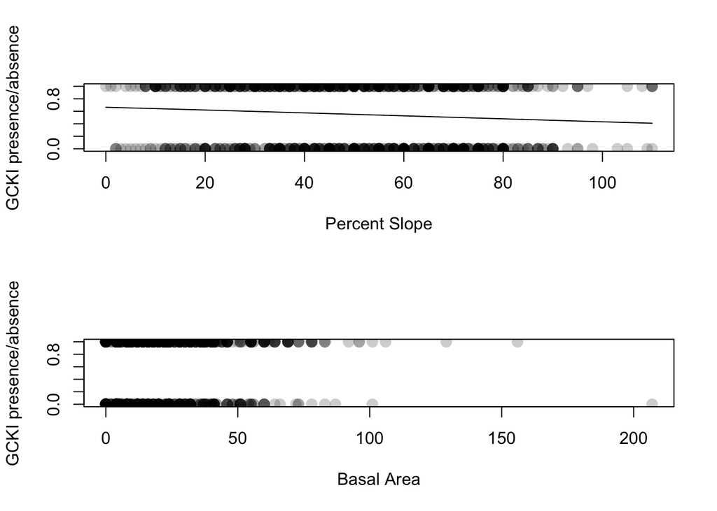

```r
par(mfrow = c(2, 1))

# Presence/absence data, translucent points:
plot(
  GCKI_pres ~ slope, data = dat_all,
  xlab = "Percent Slope",
  ylab = "GCKI presence/absence",
  pch = 16, cex = 1.5, col = gray(0, 0.2)
)

lines(gcki_predicted ~ slope, data = slope_newdata)

plot(
  GCKI_pres ~ ba.tot, data = dat_all,
  xlab = "Basal Area",
  ylab = "GCKI presence/absence",
  pch = 16, cex = 1.5, col = gray(0, 0.2)
)
```

**Q7 (4 pts.): Include contour plots (or interactive 3D perspective plots) in your report.**

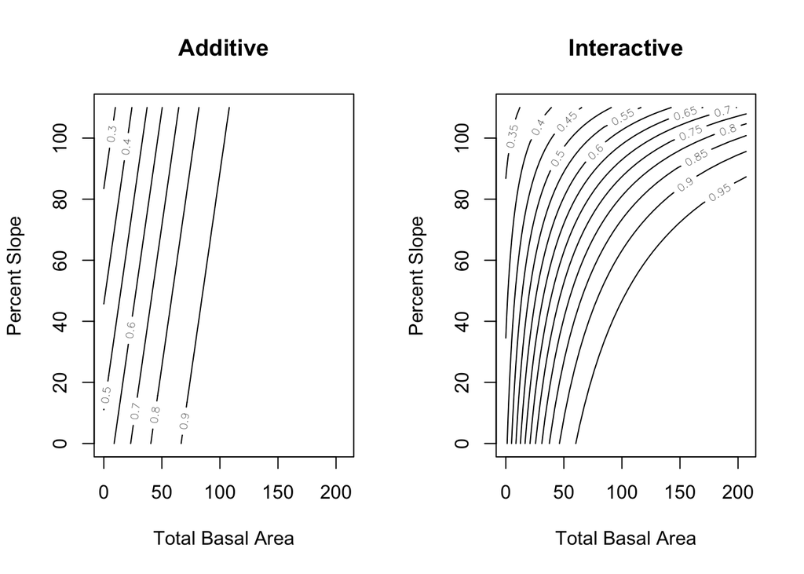

```r
par(mfrow = c(1, 2))
contour(
  x = ba.tot, y = slope,
  z = z_gcki_add,
  xlab = "Total Basal Area",
  ylab = "Percent Slope",
  main = "Additive")
contour(
  x = ba.tot,
  y = slope,
  z = z_gcki_int,
  xlab = "Total Basal Area",
  ylab = "Percent Slope",
  main = "Interactive")
```